# Simulation of 4 Linear Models

Ryan Durfey

Monday, October 20, 2014

```r
set.seed(1112131415)

# Slope and intercept for all 4 models.
a<-0.8
b<-0.1
nSample<-1000
```

### Model 1: Normal X, Normal Eps

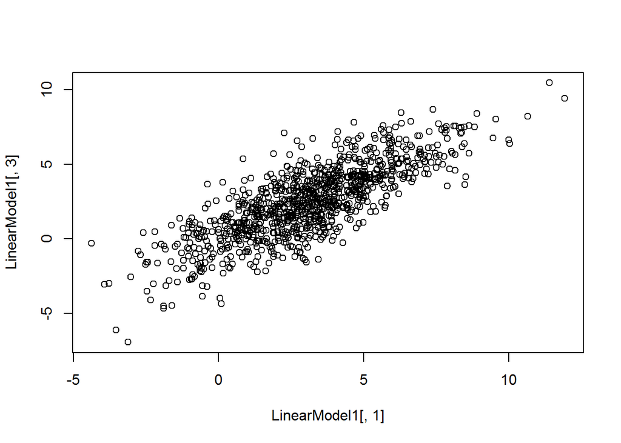

```r
X<-rnorm(n=nSample,mean=3,sd=2.5)
Eps<-rnorm(n=nSample,mean=0,sd=1.5)
Y<-a*X+b+Eps
LinearModel1<-cbind(X,Eps,Y)
plot(LinearModel1[,1],LinearModel1[,3])
```

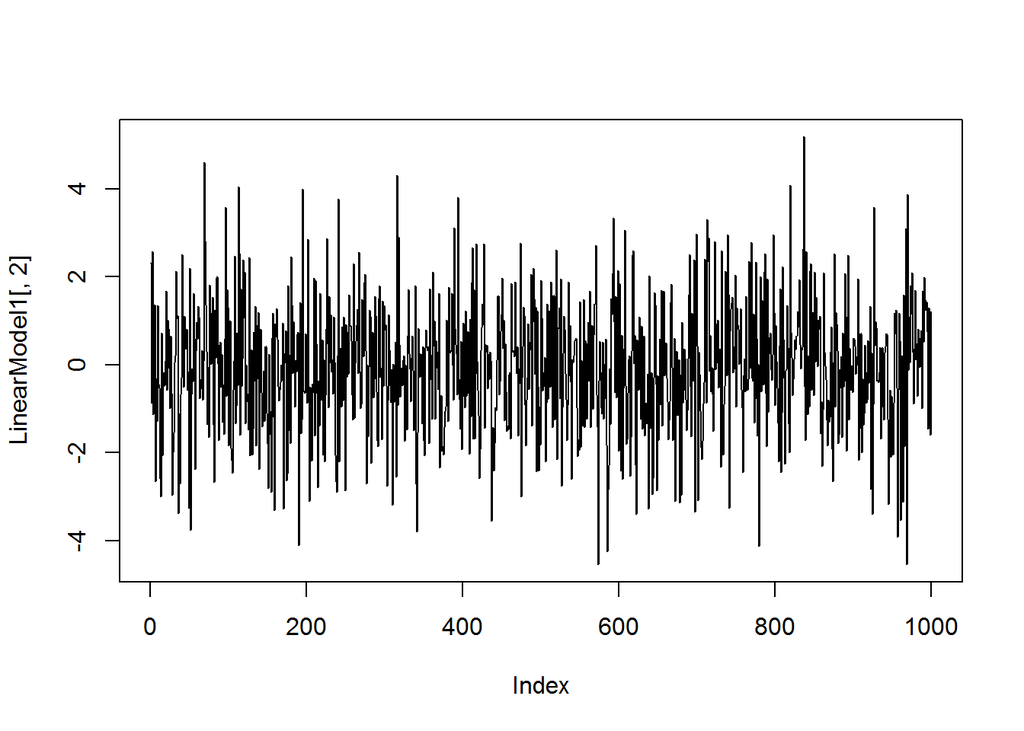

```r
# Plot of the residuals (the noise/epsilon)
plot(LinearModel1[,2],type="l")
```

### Model 2: Normal X, Uniform Eps

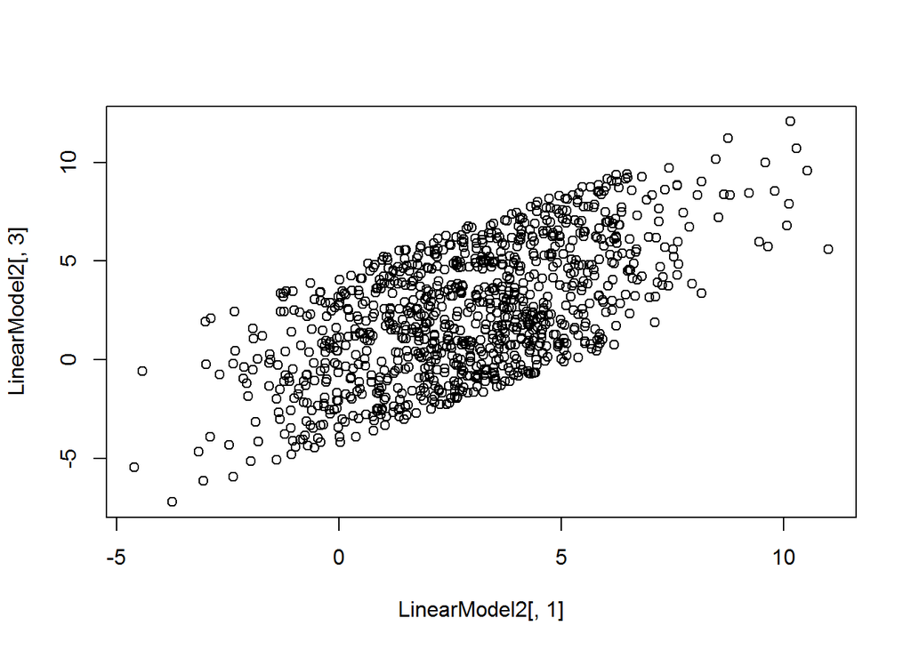

```r
X<-rnorm(n=nSample,mean=3,sd=2.5)
Eps<-runif(n=nSample,min=-4.33,max=4.33)
Y<-a*X+b+Eps
LinearModel2<-cbind(X,Eps,Y)
plot(LinearModel2[,1],LinearModel2[,3])
```

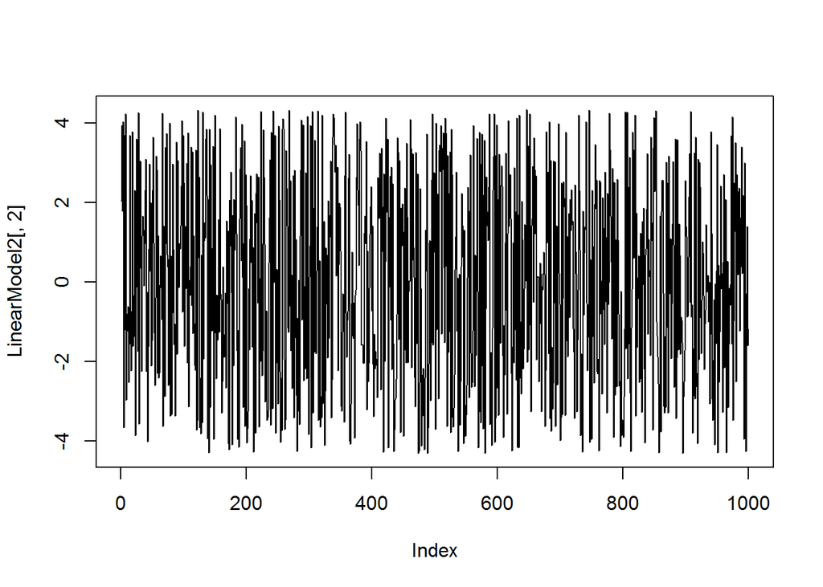

```r
# Plot of the residuals
plot(LinearModel2[,2],type="l")
```

### Model 3: Normal X, Cauchy Eps

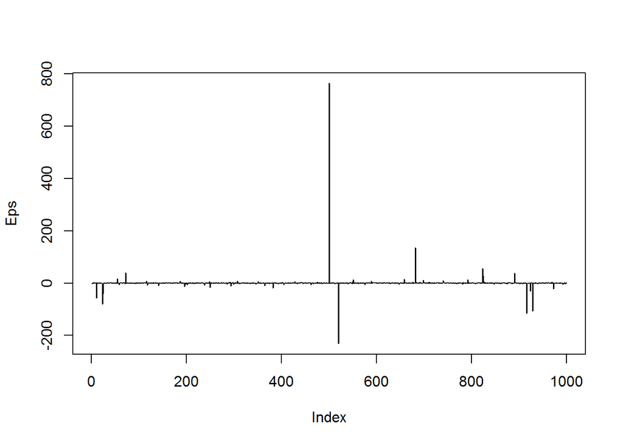

```r
X<-rnorm(n=nSample,mean=3,sd=2.5)
Eps<-rcauchy(n=nSample,location=0,scale=.3)

# Plot of the trajectory of the residuals
plot(Eps,type="l")
```

```r
# Standard deviation of the residuals
sd(Eps)
```

```
## [1] 26.48
```

```r
# Another 5 samples of residuals' standard deviations
Eps1<-rcauchy(n=nSample,location=0,scale=.3)
Eps2<-rcauchy(n=nSample,location=0,scale=.3)
Eps3<-rcauchy(n=nSample,location=0,scale=.3)
Eps4<-rcauchy(n=nSample,location=0,scale=.3)
Eps5<-rcauchy(n=nSample,location=0,scale=.3)
c(sd(Eps1),sd(Eps2),sd(Eps3),sd(Eps4),sd(Eps5))
```

```
## [1]  70.977 989.782  10.673   6.734  21.854
```

Here, we observe the jumping around of the estimates of the standard deviation of residuals. This tells us that not only can the Eps wildly influence our data points, but that it will not even do so consistently. Since the amount in which the Eps will influence the data points cannot be determined or estimated, it makes the unpredictability even more so.

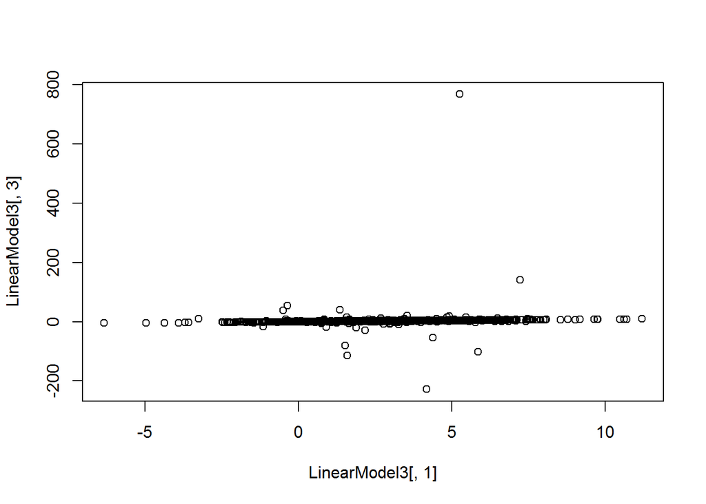

```r
# Model3 and plot
Y<-a*X+b+Eps
LinearModel3<-cbind(X,Eps,Y)
plot(LinearModel3[,1],LinearModel3[,3])
```

### Model 4: Normal X, Non-homoscedastic (heteroscedastic) Eps

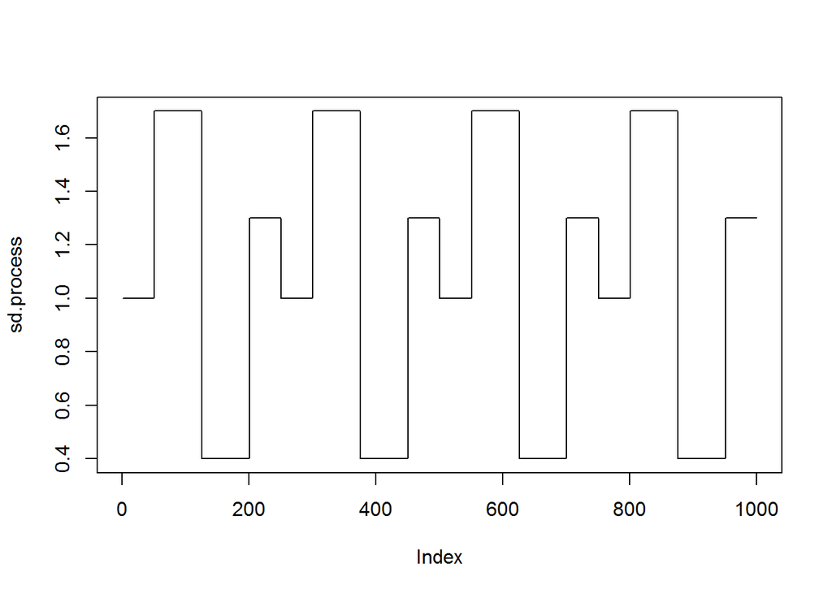

```r
X<-rnorm(n=nSample,mean=3,sd=2.5)

# Plot of trajectory of standard deviations. Same length as nSample, which is 1000.
sd.Values<-c(1,1.7,0.4,1.3)
sd.process<-rep(c(rep(sd.Values[1],50),rep(sd.Values[2],75),rep(sd.Values[3],75),rep(sd.Values[4],50)),4)
plot(sd.process,type="l")
```

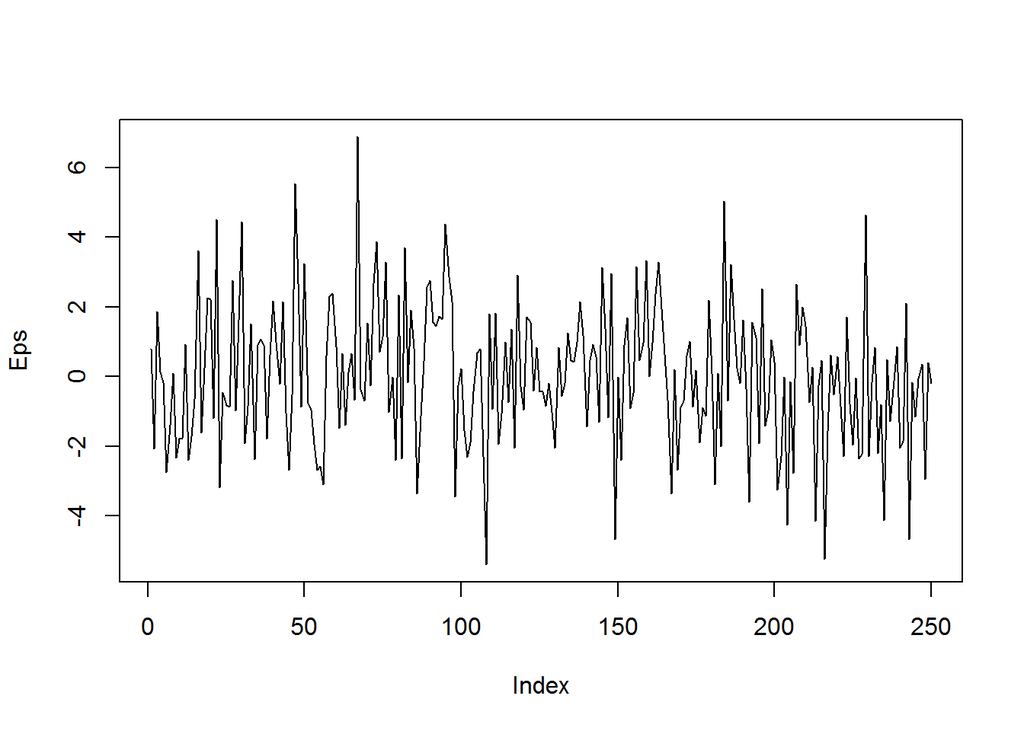

```r
# Linear model residuals, Eps, with changing standard deviations.
Eps<-rep(c(rnorm(n=50,mean=0,sd=2*sd.process[1]),rnorm(n=75,mean=0,sd=2*sd.process[2]),rnorm(n=75,mean=0,sd=2*sd.process[3]),rnorm(n=50,mean=0,sd=2*sd.process[4])))

# Plot of residuals
plot(Eps,type="l")
```

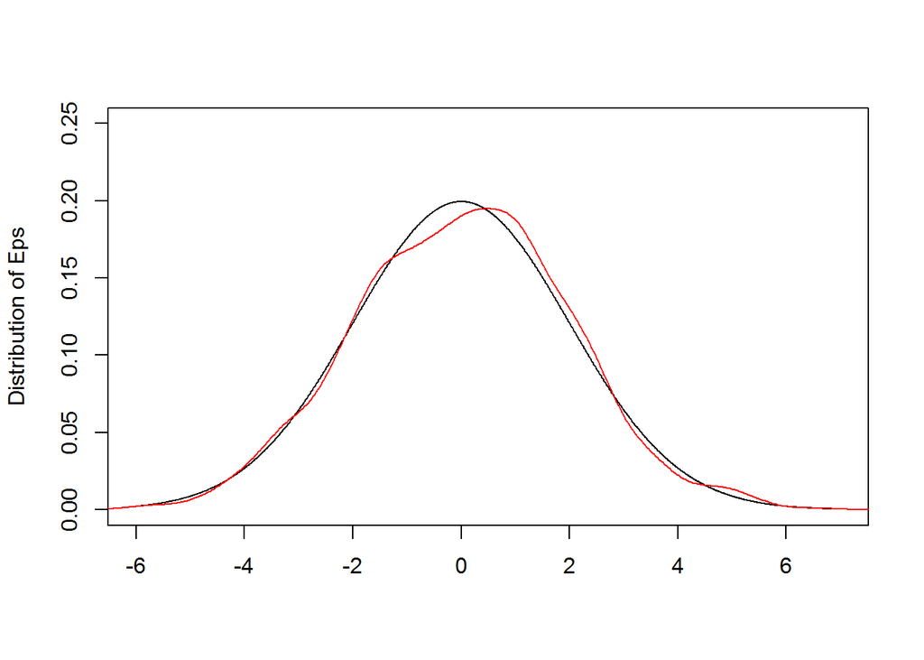

```r
EpsLong<-rep(c(rnorm(n=500,mean=0,sd=2*sd.process[1]),rnorm(n=750,mean=0,sd=2*sd.process[2]),rnorm(n=750,mean=0,sd=2*sd.process[3]),rnorm(n=500,mean=0,sd=2*sd.process[4])))

Xvariable<-(100*floor(min(Eps))):(100*ceiling(max(Eps)))
Xvariable<-Xvariable/100

# Plot of the sample distribution and the theoretical distribution.
plot(Xvariable,dnorm(Xvariable,mean=0,sd=2),type="l",ylim=c(0,.25),col="black",ylab="Distribution of Eps",xlab="")
lines(density(EpsLong),col="red")
```

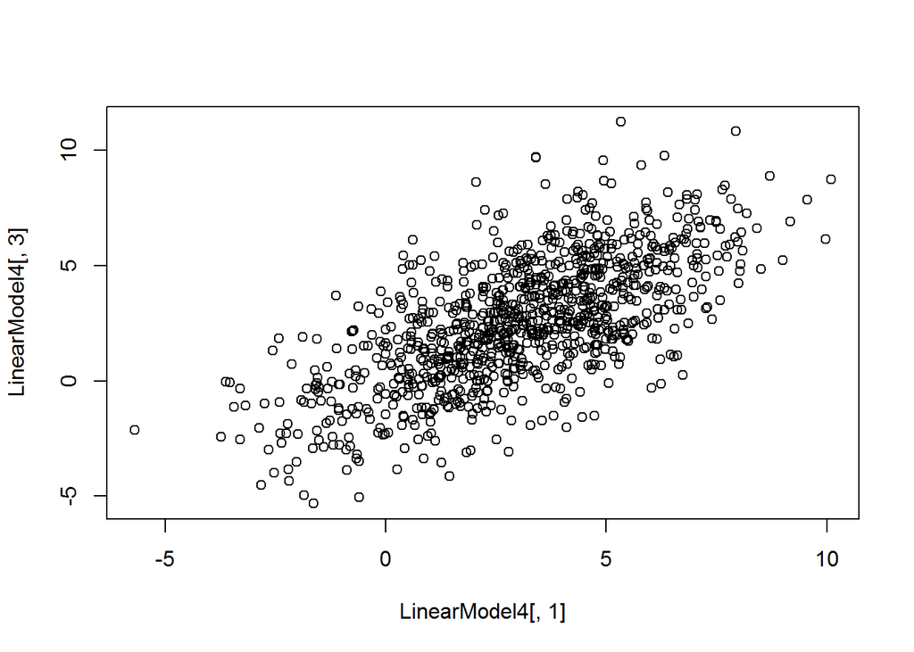

```r
# Model 4 plot
Y<-a*X+b+Eps
LinearModel4<-cbind(X,Eps,Y)
plot(LinearModel4[,1],LinearModel4[,3])
```

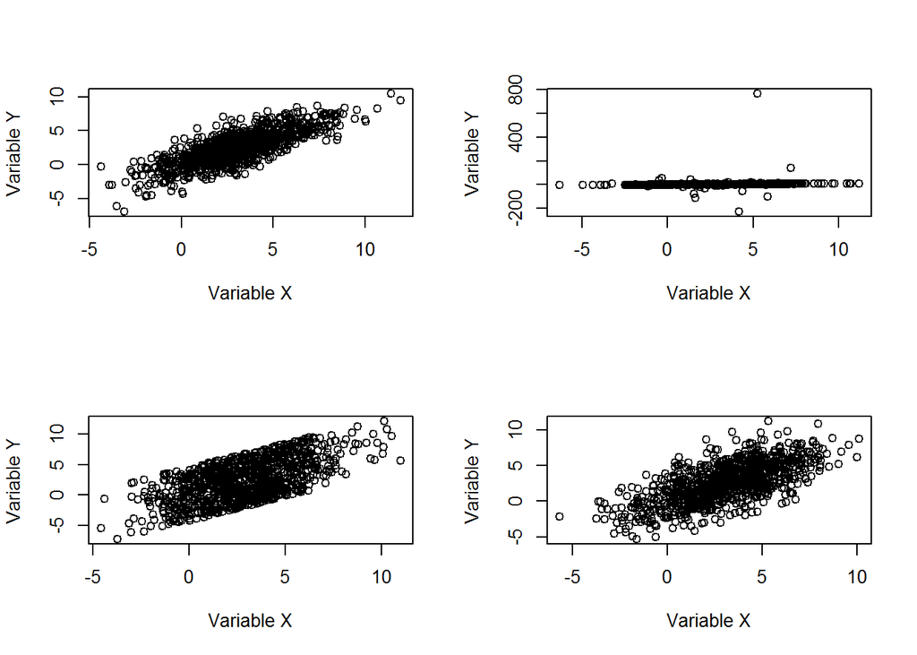

```r
# X-Y Charts for all 4 models together
layout(matrix(1:4,ncol=2))
plot(LinearModel1[,1],LinearModel1[,3],ylab="Variable Y",xlab="Variable X")
plot(LinearModel2[,1],LinearModel2[,3],ylab="Variable Y",xlab="Variable X")
plot(LinearModel3[,1],LinearModel3[,3],ylab="Variable Y",xlab="Variable X")
plot(LinearModel4[,1],LinearModel4[,3],ylab="Variable Y",xlab="Variable X")
```

```r
# Theoretical Rho-squared for Model 1
Theoretical.Rho.Squared<-(.8*2.5)^2/((.8*2.5)^2+1.5^2)
Theoretical.Rho.Squared
```

```
## [1] 0.64
```

```r
# Estimated Rho-squared using lm function for all models.
c(Model1.r.sqaured=summary(lm(LinearModel1[,3]~LinearModel1[,1]))$r.squared,Model2.r.sqaured=summary(lm(LinearModel2[,3]~LinearModel2[,1]))$r.squared,Model3.r.sqaured=summary(lm(LinearModel3[,3]~LinearModel3[,1]))$r.squared,Model4.r.sqaured=summary(lm(LinearModel4[,3]~LinearModel4[,1]))$r.squared)
```

```
## Model1.r.sqaured Model2.r.sqaured Model3.r.sqaured Model4.r.sqaured
##          0.63605          0.38038          0.01028          0.44695
```

These results of the estimated rho-squared for the models shows us a few things.

First, calculating rho-squared with the theoretical method gives us a similar, but not exactly identical value as when using the lm function. This is likely simply due to rounding.

Second, the only model that gives us a decent determination coefficient (rho-squared) is Model 1. All the others are below 0.50, which is not very strong at all.

Lastly, the rho-squared for Model 3 is so incredibly low that it really shows how erratic the Cauchy distribution really is. It is much closer to zero than to anything we could consider a fairly strong value.

```r
# Estimate of parameters a, b, and sigma using the lm function.
summary(lm(LinearModel1[,3]~LinearModel1[,1]))
```

```
##
## Call:
## lm(formula = LinearModel1[, 3] ~ LinearModel1[, 1])
##
## Residuals:
##    Min     1Q Median     3Q    Max
## -4.473 -0.894  0.010  0.938  5.256
##
## Coefficients:
##                   Estimate Std. Error t value Pr(>|t|)
## (Intercept)         0.0291     0.0752    0.39      0.7
## LinearModel1[, 1]   0.7984     0.0191   41.76   <2e-16 ***
## ---
## Signif. codes:  0 '***' 0.001 '**' 0.01 '*' 0.05 '.' 0.1 ' ' 1
##
## Residual standard error: 1.47 on 998 degrees of freedom
## Multiple R-squared:  0.636,  Adjusted R-squared:  0.636
## F-statistic: 1.74e+03 on 1 and 998 DF,  p-value: <2e-16
```

```r
# Estimate of parameters a, b, and sigma using lm function and Method of Moments.
aEstimate<-cov(LinearModel1[,3],LinearModel1[,1])/var(LinearModel1[,1])
bEstimate<-mean(LinearModel1[,3])-aEstimate*mean(LinearModel1[,1])
sigmaEstimate<-sqrt(var(LinearModel1[,3]-aEstimate*LinearModel1[,1]))
c(aEstimate,bEstimate,sigmaEstimate)
```

```
## [1] 0.79840 0.02908 1.46997
```

From the four models, we see that the assumptions that were used to generate the data greatly affected the model behavior and estimated parameters. Model 1, which utilized normal Eps, was by far the “best” and created the strongest linear model. Model 2, using a uniform Eps, resulted in a plot of points that look uniformly distributed between two parallel lines. Model 3 was easily the craziest of the bunch, resulting in an extremely weak linear model. The Eps generated with the Cauchy distribution were just too erratic and influenced the data too much and too unpredictably. Lastly, Model 4 appeared at first to look similar to Model 1 when it was plotted. However, calculation of rho-squared showed us that it is in fact much weaker than Model 1. This also tells us that just a little variation of Eps, even non-random variation, will affect the overall linear model.